# Sismicidad M≥5 en México y su entorno

[figure not shown]

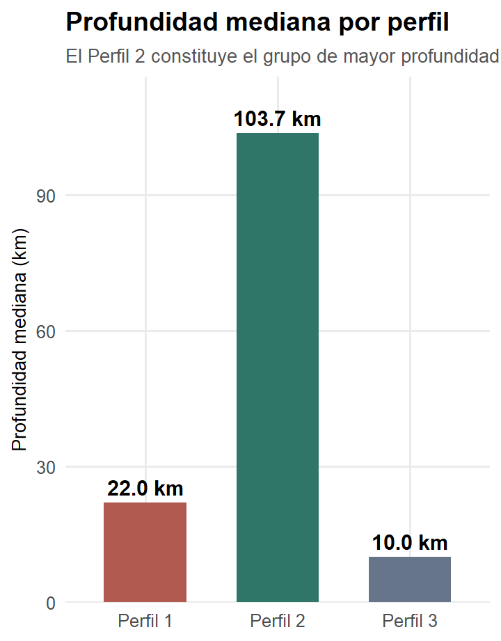

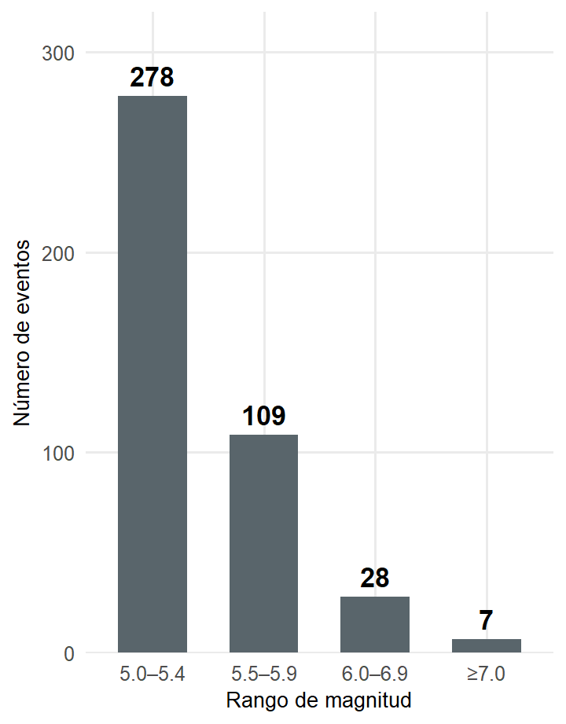

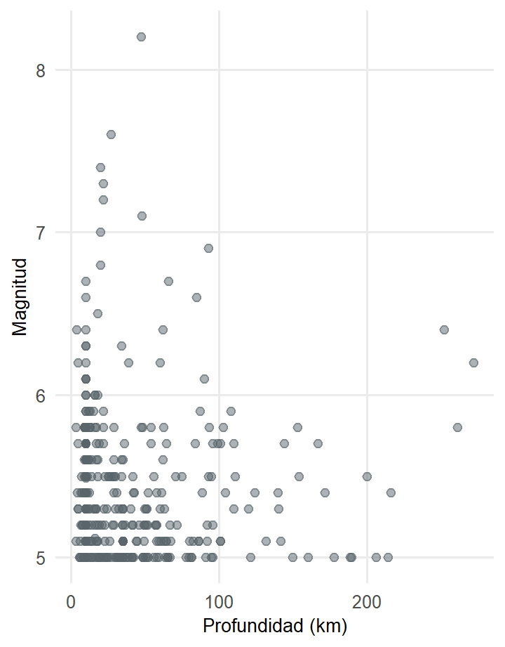

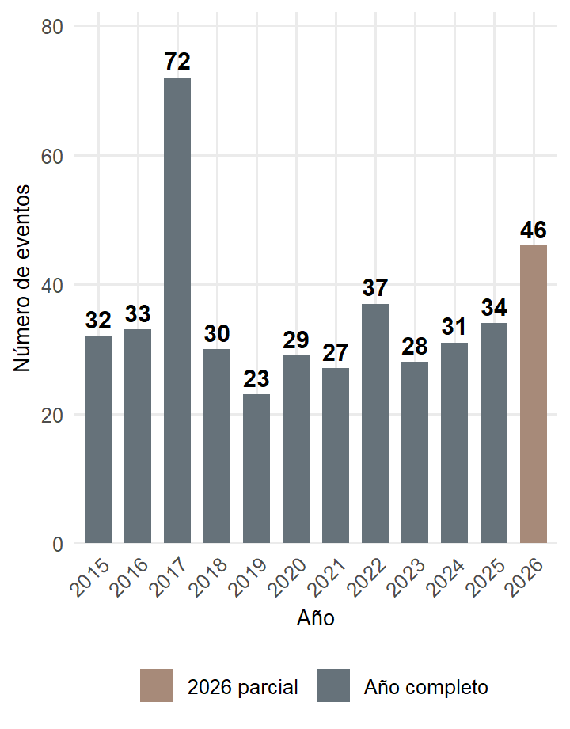

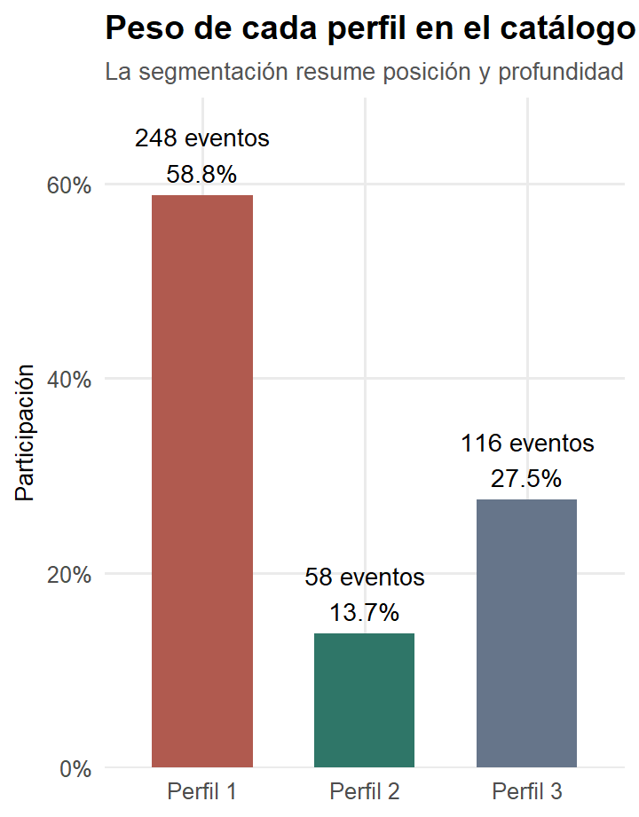

[figure not shown]

[figure not shown]

[figure not shown]

# Panorama

### Eventos analizados

422

### Magnitud máxima

8.2

### Profundidad mediana

17.0 km

### Calidad K-Means

0.528

### ¿Dónde aparecen los perfiles?

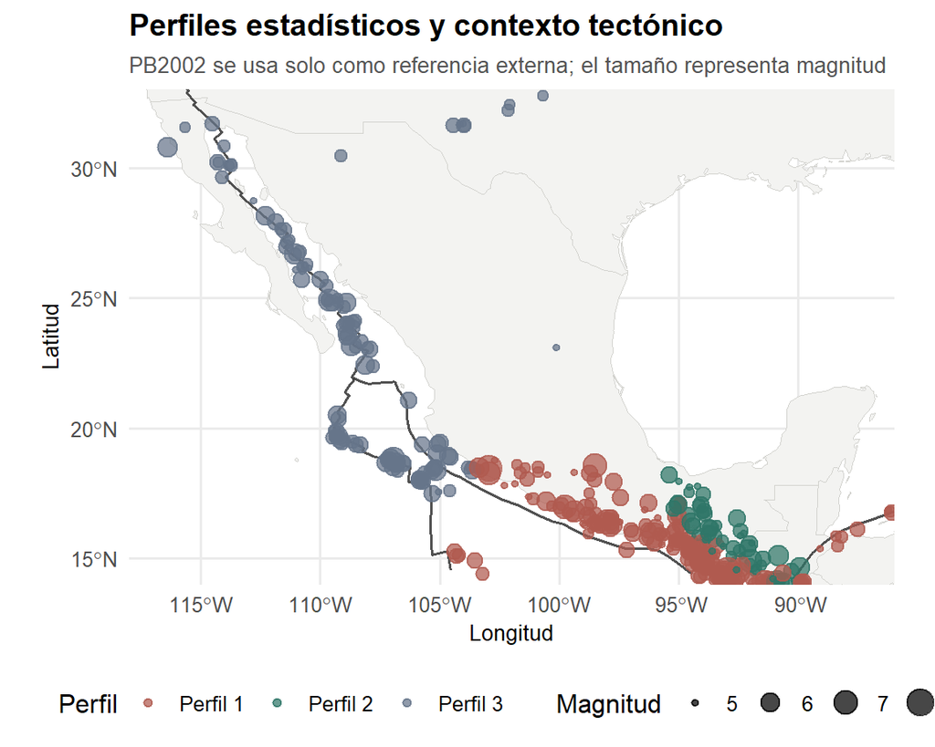

### La profundidad separa los perfiles

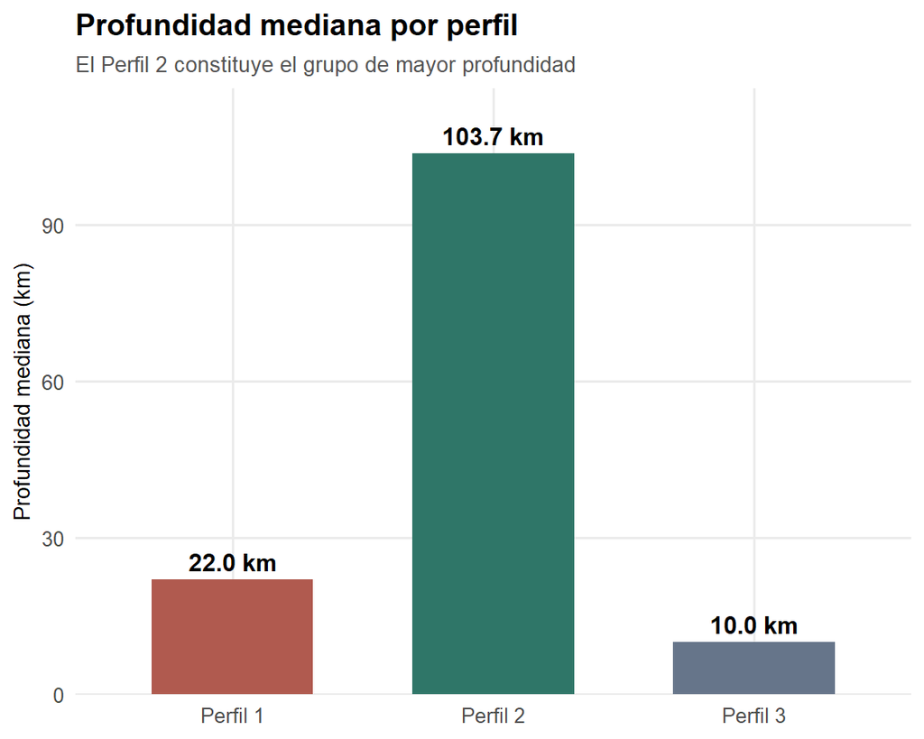

**Lectura principal.** Los eventos no se distribuyen de forma homogénea. K-Means resume el catálogo en tres perfiles definidos por localización y profundidad; el Perfil 2 destaca por una profundidad mediana cercana a 104 km. Los perfiles son estadísticos, no regiones tectónicas oficiales.

# Patrones del catálogo

### Eventos menores a M6

91.7%

### Eventos a menos de 70 km

85.5%

### Profundidad vs. magnitud

-0.09

### Periodo 2026

Parcial

### A mayor magnitud, menos eventos

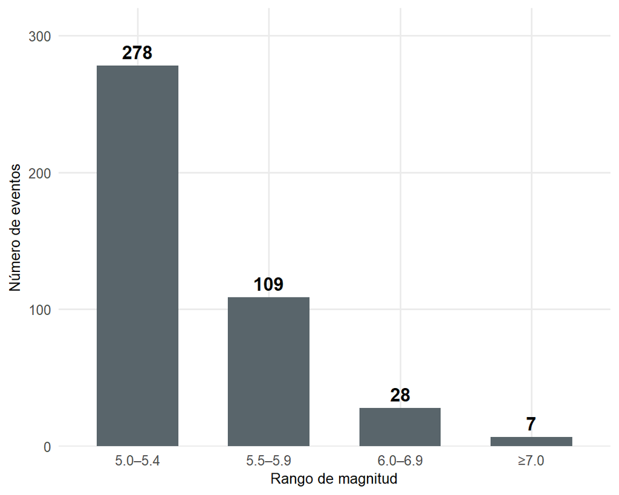

### ¿Qué vemos?

**Los eventos grandes son mucho menos frecuentes.**

De los 422 sismos analizados, la gran mayoría se encuentra cerca del umbral de magnitud 5.

Solo una proporción pequeña alcanza magnitudes de 6 o más.

**Idea clave:** conforme aumenta la magnitud, disminuye claramente el número de eventos registrados.

### Profundidad y magnitud no muestran una relación clara

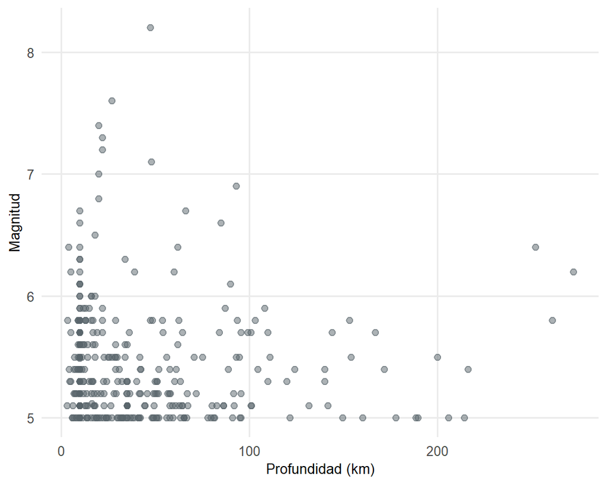

### ¿Qué vemos?

**Un sismo más profundo no necesariamente es más fuerte.**

Los puntos aparecen dispersos y no forman una tendencia clara.

La correlación obtenida fue de aproximadamente **-0.09**, es decir, muy cercana a cero.

**Idea clave:** dentro de esta muestra, la profundidad no explica la magnitud del evento.

### La cantidad de eventos cambia entre años

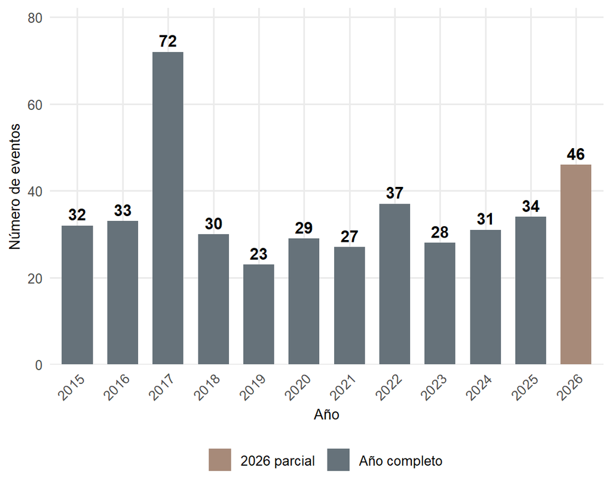

### ¿Qué vemos?

**El número de eventos registrados cambia de un año a otro.**

No se observa un incremento continuo durante todo el periodo.

2026 aparece destacado porque solo contiene información hasta el **19 de septiembre**.

**Idea clave:** esta gráfica describe variación temporal, pero no demuestra por sí sola que la actividad sísmica esté aumentando.

# Modelo y sensibilidad

### Cómo se eligió K = 3

**K-Means es el modelo principal.** La Silhouette favorece una solución más parsimoniosa con K = 2, pero K = 3 conserva una calidad cercana y permite separar un perfil profundo claramente interpretable. El codo y el Gap Statistic se usan como criterios complementarios. Por ello, K = 3 se interpreta como una segmentación descriptiva útil, no como prueba de tres poblaciones sísmicas naturalmente separadas.

### Qué distingue a los perfiles

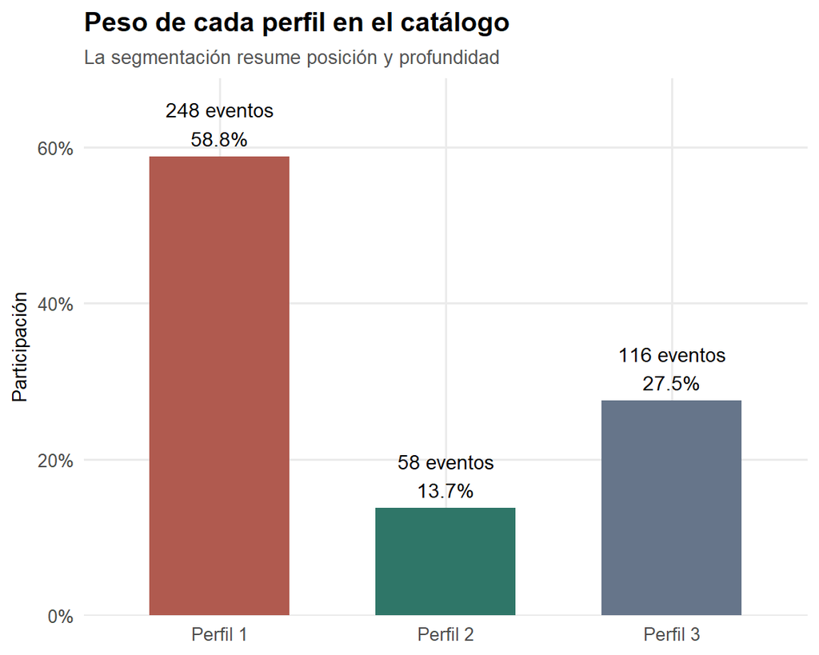

### Magnitud como contraste externo

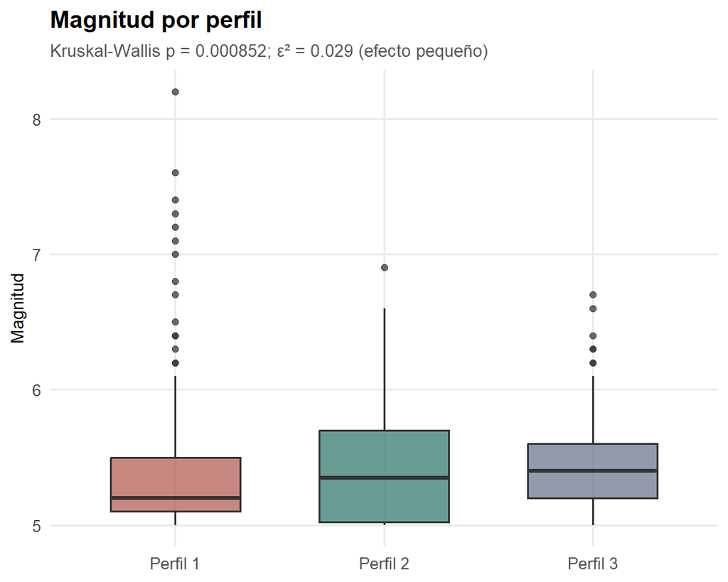

### DBSCAN: qué cambia con otro supuesto

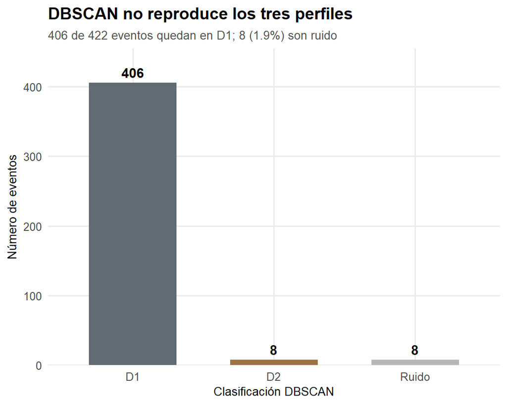

### Interpretación de sensibilidad

**Resultado clave.** DBSCAN encuentra una estructura basada en densidad mucho menos fragmentada que K-Means. Esto indica que la partición exacta de tres perfiles depende del supuesto del algoritmo. La comparación fortalece el análisis porque evita presentar K = 3 como una verdad geológica o como tres poblaciones naturalmente separadas.

La magnitud no participa en la construcción de K-Means; se utiliza después para caracterizar los grupos. Esto evita una validación circular.

# Conclusiones

### Mensaje final

**El hallazgo principal:** los eventos se diferencian mucho más por **dónde ocurren y a qué profundidad** que por su magnitud. K-Means ayuda a resumir esa heterogeneidad en tres perfiles, pero DBSCAN muestra que esos tres perfiles no deben interpretarse como tres poblaciones naturales ni como regiones tectónicas definitivas.

### La profundidad es la diferencia más visible entre perfiles

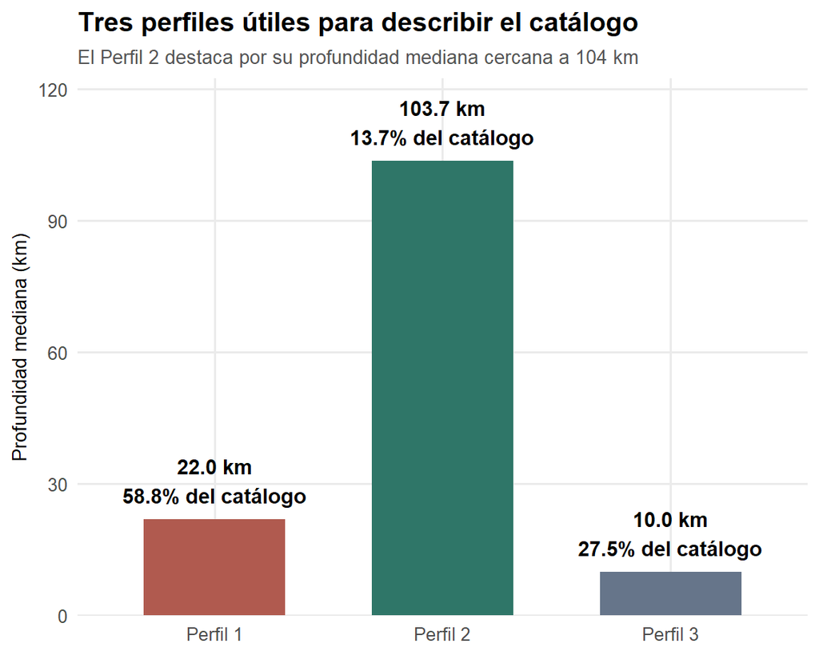

### Cómo interpretar el modelo

**1. Qué encontramos.**  
Tres perfiles con combinaciones distintas de localización y profundidad.

**2. Qué aporta K-Means.**  
Resume 422 eventos en grupos fáciles de comparar y hace visible el perfil profundo.

**3. Qué nos advierte DBSCAN.**  
96.2% de los eventos cae en un solo grupo de densidad. Por eso los tres perfiles son una segmentación útil, no tres grupos “naturales”.

**4. Qué papel juega la magnitud.**  
Ayuda a caracterizar los perfiles después del agrupamiento, pero las diferencias son pequeñas frente a las de profundidad y localización.

### Lo que sí aporta este proyecto

**Sí permite:**

✓ describir dónde y a qué profundidad se concentran los eventos M≥5;  
✓ resumir el catálogo en perfiles comparables;  
✓ identificar un perfil de eventos claramente más profundos;  
✓ comprobar que la conclusión depende del método de agrupamiento y comunicar esa limitación.

### Lo que no debe concluirse

**No implica:**

✗ que existan exactamente tres tipos naturales de sismos;  
✗ que cada perfil corresponda a una placa tectónica específica;  
✗ que profundidad determine magnitud;  
✗ que el análisis permita predecir cuándo o dónde ocurrirá el siguiente sismo.

### Alcance de los datos

**Fuente:** USGS ComCat | **Periodo:** 2015-01-01 a 2026-09-19 | **Dominio:** 14°–33° N y −118°–−86°.

````r
---
title: "Sismicidad M≥5 en México y su entorno"
author: "Karla Valeria Loyola Alarcón"
output:
  flexdashboard::flex_dashboard:
    orientation: rows
    vertical_layout: scroll
    theme: yeti
    source_code: embed
---

```{r setup, include=FALSE}
knitr::opts_chunk$set(
  echo = FALSE,
  warning = FALSE,
  message = FALSE,
  fig.align = "center",
  fig.retina = 2
)

paquetes <- c(
  "flexdashboard", "tidyverse", "lubridate", "sf",
  "cluster", "maps", "scales"
)

faltantes <- paquetes[!vapply(paquetes, requireNamespace, logical(1), quietly = TRUE)]

if (length(faltantes) > 0) {
  stop(
    paste0(
      "Instala primero estos paquetes: ",
      paste(faltantes, collapse = ", ")
    )
  )
}

library(flexdashboard)
library(tidyverse)
library(lubridate)
library(sf)
library(cluster)
library(maps)
library(scales)

# -----------------------------------------------------------------------------
# Archivos del proyecto
# -----------------------------------------------------------------------------
archivo_dashboard <- file.path("data", "processed", "sismos_dashboard.csv")
archivo_placas <- file.path("data", "external", "PB2002_boundaries.json")

if (!file.exists(archivo_dashboard)) {
  stop(
    paste0(
      "No se encontró '", archivo_dashboard, "'. ",
      "Primero renderiza ANALISIS_SISMOS_FINAL.Rmd para generar la base procesada."
    )
  )
}

sismos <- readr::read_csv(
  archivo_dashboard,
  show_col_types = FALSE
)

# La exportación del reporte conserva el número de clúster de K-Means.
sismos <- sismos %>%
  mutate(
    cluster_num = readr::parse_number(as.character(cluster_kmeans)),
    perfil = factor(
      cluster_num,
      levels = c(1, 2, 3),
      labels = c("Perfil 1", "Perfil 2", "Perfil 3")
    ),
    perfil_descriptivo = factor(
      cluster_num,
      levels = c(1, 2, 3),
      labels = c(
        "Sur-sureste\nsomero/intermedio",
        "Sureste\nprofundo",
        "Occidente-noroeste\nsuperficial"
      )
    ),
    cluster_dbscan = as.character(cluster_dbscan)
  )

# Fecha para análisis temporal.
if (!inherits(sismos$fecha_hora, "POSIXct")) {
  sismos <- sismos %>%
    mutate(
      fecha_hora = suppressWarnings(
        lubridate::ymd_hms(fecha_hora, tz = "UTC", quiet = TRUE)
      )
    )
}

sismos <- sismos %>%
  mutate(
    fecha = as.Date(fecha_hora),
    anio = lubridate::year(fecha_hora)
  )

# -----------------------------------------------------------------------------
# Métricas generales
# -----------------------------------------------------------------------------
n_eventos <- nrow(sismos)
magnitud_maxima <- max(sismos$mag, na.rm = TRUE)
profundidad_mediana <- median(sismos$depth, na.rm = TRUE)

# Silhouette de la asignación final de K-Means, reconstruida con las mismas
# variables utilizadas en el reporte: X, Y y profundidad estandarizadas.
puntos_sf <- st_as_sf(
  sismos,
  coords = c("longitude", "latitude"),
  crs = 4326,
  remove = FALSE
)

puntos_lcc <- st_transform(puntos_sf, 6372)
coord_lcc <- st_coordinates(puntos_lcc)

X_dashboard <- sismos %>%
  transmute(
    X = coord_lcc[, 1],
    Y = coord_lcc[, 2],
    Profundidad = depth
  ) %>%
  scale()

sil_dashboard <- cluster::silhouette(
  sismos$cluster_num,
  dist(X_dashboard)
)

silhouette_global <- mean(sil_dashboard[, "sil_width"])

# Correlación profundidad-magnitud.
cor_spearman <- cor.test(
  sismos$depth,
  sismos$mag,
  method = "spearman",
  exact = FALSE
)

rho <- unname(cor_spearman$estimate)
p_spearman <- cor_spearman$p.value

# Contraste externo de magnitud entre perfiles.
kw <- kruskal.test(mag ~ perfil, data = sismos)
H_kw <- unname(kw$statistic)
k_kw <- nlevels(sismos$perfil)
epsilon2 <- (H_kw - k_kw + 1) / (n_eventos - k_kw)

# Resumen por perfil.
perfil_resumen <- sismos %>%
  group_by(perfil, perfil_descriptivo) %>%
  summarise(
    eventos = n(),
    porcentaje = 100 * eventos / n_eventos,
    profundidad_mediana = median(depth, na.rm = TRUE),
    magnitud_mediana = median(mag, na.rm = TRUE),
    .groups = "drop"
  )

# Frecuencia acumulada por umbral de magnitud.
umbrales <- seq(
  5,
  floor(max(sismos$mag, na.rm = TRUE) * 10) / 10,
  by = 0.1
)

frecuencia_magnitud <- tibble(
  umbral = umbrales,
  eventos = map_int(
    umbrales,
    ~ sum(sismos$mag >= .x, na.rm = TRUE)
  )
) %>%
  filter(eventos > 0)

# Conteo anual. 2026 es un año parcial.
eventos_anio <- sismos %>%
  count(anio, name = "eventos") %>%
  mutate(
    periodo = if_else(anio == 2026, "2026 parcial", "Año completo")
  )

# Categorías descriptivas de profundidad.
profundidad_categoria <- sismos %>%
  mutate(
    categoria = case_when(
      depth < 70 ~ "Superficial (<70 km)",
      depth < 300 ~ "Intermedia (70–300 km)",
      TRUE ~ "Profunda (≥300 km)"
    ),
    categoria = factor(
      categoria,
      levels = c(
        "Superficial (<70 km)",
        "Intermedia (70–300 km)",
        "Profunda (≥300 km)"
      )
    )
  ) %>%
  count(categoria, name = "eventos") %>%
  mutate(porcentaje = 100 * eventos / sum(eventos))

# DBSCAN: resumen directamente desde la clasificación exportada.
dbscan_resumen <- sismos %>%
  count(cluster_dbscan, name = "eventos") %>%
  mutate(
    cluster_dbscan = factor(
      cluster_dbscan,
      levels = c("D1", "D2", "Ruido")
    )
  ) %>%
  arrange(cluster_dbscan)

n_ruido <- sum(sismos$cluster_dbscan == "Ruido", na.rm = TRUE)
porcentaje_ruido <- 100 * n_ruido / n_eventos
n_d1 <- sum(sismos$cluster_dbscan == "D1", na.rm = TRUE)
porcentaje_d1 <- 100 * n_d1 / n_eventos

# Métricas pensadas para comunicar los hallazgos de forma no técnica.
porcentaje_menor_6 <- 100 * mean(sismos$mag < 6, na.rm = TRUE)
porcentaje_superficial <- 100 * mean(sismos$depth < 70, na.rm = TRUE)

perfil_2_profundidad <- perfil_resumen %>%
  filter(perfil == "Perfil 2") %>%
  pull(profundidad_mediana)

# Rangos simples de magnitud para una lectura inmediata.
magnitud_rangos <- sismos %>%
  mutate(
    rango_magnitud = case_when(
      mag < 5.5 ~ "5.0–5.4",
      mag < 6.0 ~ "5.5–5.9",
      mag < 7.0 ~ "6.0–6.9",
      TRUE ~ "≥7.0"
    ),
    rango_magnitud = factor(
      rango_magnitud,
      levels = c("5.0–5.4", "5.5–5.9", "6.0–6.9", "≥7.0")
    )
  ) %>%
  count(rango_magnitud, name = "eventos") %>%
  tidyr::complete(
    rango_magnitud,
    fill = list(eventos = 0)
  )
````

````r
# -----------------------------------------------------------------------------
# Contexto tectónico externo
# -----------------------------------------------------------------------------
min_lon <- -118
max_lon <- -86
min_lat <- 14
max_lat <- 33

limites_estudio <- NULL

if (file.exists(archivo_placas)) {
  limites_placas <- st_read(archivo_placas, quiet = TRUE)

  if (is.na(st_crs(limites_placas))) {
    st_crs(limites_placas) <- 4326
  }

  bbox_estudio <- st_bbox(
    c(
      xmin = min_lon,
      ymin = min_lat,
      xmax = max_lon,
      ymax = max_lat
    ),
    crs = st_crs(4326)
  )

  limites_estudio <- st_crop(limites_placas, bbox_estudio)
}

mapa_mundo <- map_data("world")

# Paleta sobria y constante en todo el dashboard.
colores_perfil <- c(
  "Perfil 1" = "#B05A4F",
  "Perfil 2" = "#2F7668",
  "Perfil 3" = "#66758A"
)

colores_dbscan <- c(
  "D1" = "#626B72",
  "D2" = "#9B7442",
  "Ruido" = "#B7B7B7"
)

tema_dashboard <- theme_minimal(base_size = 12) +
  theme(
    plot.title = element_text(face = "bold", size = 14),
    plot.subtitle = element_text(size = 10, colour = "#555555"),
    panel.grid.minor = element_blank(),
    legend.position = "bottom",
    axis.title = element_text(size = 10)
  )
```



<style>
.side-note {
  background: #eef1f0;
  border-left: 5px solid #52675e;
  padding: 22px 24px;
  margin: 8px 12px;
  font-size: 16px;
  line-height: 1.55;
}

.side-note strong {
  color: #30383b;
}

.navbar-inverse {
  background-color: #30363a;
  border-color: #30363a;
}
.navbar-inverse .navbar-brand,
.navbar-inverse .navbar-nav > li > a {
  color: #ffffff;
}
.value-box {
  border-radius: 4px;
}
.chart-title {
  font-weight: 600;
}
.insight-box {
  background: #f5f4f1;
  border-left: 4px solid #6f655d;
  padding: 14px 16px;
  margin: 6px 0 12px 0;
  line-height: 1.45;
}
.small-note {
  color: #666666;
  font-size: 12px;
}
.takeaway-box {
  background: #eef1f0;
  border-left: 5px solid #4f635b;
  padding: 14px 18px;
  margin: 6px 0 12px 0;
  line-height: 1.45;
  font-size: 14px;
}
.final-message {
  background: #30363a;
  color: #ffffff;
  padding: 16px 20px;
  border-radius: 4px;
  margin: 4px 0 10px 0;
  font-size: 17px;
  line-height: 1.45;
}
.yes-box {
  background: #eef3f0;
  border-left: 4px solid #587064;
  padding: 14px 16px;
  line-height: 1.5;
  min-height: 190px;
}
.no-box {
  background: #f5f0ee;
  border-left: 4px solid #87685b;
  padding: 14px 16px;
  line-height: 1.5;
  min-height: 190px;
}
.small-note {
  color: #666666;
  font-size: 13px;
  padding: 8px 12px;
  text-align: center;
}
</style>

Panorama
=====================================

Row {data-height=115}
-------------------------------------

### Eventos analizados

```{r}
valueBox(
  format(n_eventos, big.mark = ","),
  caption = "Eventos M≥5",
  color = "#4B545A"
)
```

### Magnitud máxima

```{r}
valueBox(
  sprintf("%.1f", magnitud_maxima),
  caption = "Máxima observada",
  color = "#725B4E"
)
```

### Profundidad mediana

```{r}
valueBox(
  sprintf("%.1f km", profundidad_mediana),
  caption = "Mediana del catálogo",
  color = "#5F6A63"
)
```

### Calidad K-Means

```{r}
valueBox(
  sprintf("%.3f", silhouette_global),
  caption = "Silhouette, K = 3",
  color = "#5A6578"
)
```

Row {data-height=540}
-------------------------------------

### ¿Dónde aparecen los perfiles? {data-width=8}

```{r}
graf_mapa <- ggplot() +
  geom_polygon(
    data = mapa_mundo,
    aes(x = long, y = lat, group = group),
    fill = "#F3F3F1",
    color = "#D2D2CE",
    linewidth = 0.2
  )

if (!is.null(limites_estudio)) {
  graf_mapa <- graf_mapa +
    geom_sf(
      data = limites_estudio,
      inherit.aes = FALSE,
      linewidth = 0.60,
      color = "#333333",
      alpha = 0.85
    )
}

graf_mapa +
  geom_point(
    data = sismos,
    aes(
      x = longitude,
      y = latitude,
      color = perfil,
      size = mag
    ),
    alpha = 0.72
  ) +
  scale_color_manual(values = colores_perfil) +
  scale_size_continuous(range = c(1.3, 5.8)) +
  coord_sf(
    xlim = c(min_lon, max_lon),
    ylim = c(min_lat, max_lat),
    expand = FALSE,
    default_crs = st_crs(4326)
  ) +
  labs(
    title = "Perfiles estadísticos y contexto tectónico",
    subtitle = "PB2002 se usa solo como referencia externa; el tamaño representa magnitud",
    x = "Longitud",
    y = "Latitud",
    color = "Perfil",
    size = "Magnitud"
  ) +
  tema_dashboard
```

### La profundidad separa los perfiles {data-width=4}

```{r}
ggplot(
  perfil_resumen,
  aes(
    x = perfil,
    y = profundidad_mediana,
    fill = perfil
  )
) +
  geom_col(width = 0.62, show.legend = FALSE) +
  geom_text(
    aes(label = sprintf("%.1f km", profundidad_mediana)),
    vjust = -0.5,
    fontface = "bold",
    size = 4
  ) +
  scale_fill_manual(values = colores_perfil) +
  scale_y_continuous(
    expand = expansion(mult = c(0, 0.12))
  ) +
  labs(
    title = "Profundidad mediana por perfil",
    subtitle = "El Perfil 2 constituye el grupo de mayor profundidad",
    x = NULL,
    y = "Profundidad mediana (km)"
  ) +
  tema_dashboard +
  theme(legend.position = "none")
```

<div class="insight-box">
<strong>Lectura principal.</strong> Los eventos no se distribuyen de forma homogénea. K-Means resume el catálogo en tres perfiles definidos por localización y profundidad; el Perfil 2 destaca por una profundidad mediana cercana a 104 km. Los perfiles son estadísticos, no regiones tectónicas oficiales.
</div>

Patrones del catálogo
=====================================

Row {data-height=120}
-------------------------------------

### Eventos menores a M6

```{r}
valueBox(
  sprintf("%.1f%%", porcentaje_menor_6),
  caption = "del catálogo",
  color = "#5B646A"
)
```

### Eventos a menos de 70 km

```{r}
valueBox(
  sprintf("%.1f%%", porcentaje_superficial),
  caption = "del catálogo",
  color = "#65746B"
)
```

### Profundidad vs. magnitud

```{r}
valueBox(
  sprintf("%.2f", rho),
  caption = "Correlación muy débil",
  color = "#7A6257"
)
```

### Periodo 2026

```{r}
valueBox(
  "Parcial",
  caption = "Hasta el 19 de septiembre",
  color = "#6A6870"
)
```
````

````r
Row {data-height=430}
-------------------------------------

### A mayor magnitud, menos eventos {data-width=8}

```{r}
ggplot(
  magnitud_rangos,
  aes(
    x = rango_magnitud,
    y = eventos
  )
) +
  geom_col(
    width = 0.62,
    fill = "#59656B"
  ) +
  geom_text(
    aes(label = eventos),
    vjust = -0.5,
    fontface = "bold",
    size = 4.5
  ) +
  scale_y_continuous(
    expand = expansion(mult = c(0, 0.15))
  ) +
  labs(
    x = "Rango de magnitud",
    y = "Número de eventos"
  ) +
  tema_dashboard
```

### ¿Qué vemos? {data-width=4}

<div class="side-note">

<strong>Los eventos grandes son mucho menos frecuentes.</strong><br><br>

De los 422 sismos analizados, la gran mayoría se encuentra cerca del umbral de magnitud 5.<br><br>

Solo una proporción pequeña alcanza magnitudes de 6 o más.<br><br>

<strong>Idea clave:</strong> conforme aumenta la magnitud, disminuye claramente el número de eventos registrados.

</div>


Row {data-height=430}
-------------------------------------

### Profundidad y magnitud no muestran una relación clara {data-width=8}

```{r}
ggplot(
  sismos,
  aes(
    x = depth,
    y = mag
  )
) +
  geom_point(
    alpha = 0.5,
    size = 2,
    color = "#59656B"
  ) +
  labs(
    x = "Profundidad (km)",
    y = "Magnitud"
  ) +
  tema_dashboard
```

### ¿Qué vemos? {data-width=4}

<div class="side-note">

<strong>Un sismo más profundo no necesariamente es más fuerte.</strong><br><br>

Los puntos aparecen dispersos y no forman una tendencia clara.<br><br>

La correlación obtenida fue de aproximadamente <strong>-0.09</strong>, es decir, muy cercana a cero.<br><br>

<strong>Idea clave:</strong> dentro de esta muestra, la profundidad no explica la magnitud del evento.

</div>


Row {data-height=430}
-------------------------------------

### La cantidad de eventos cambia entre años {data-width=8}

```{r}
ggplot(
  eventos_anio,
  aes(
    x = factor(anio),
    y = eventos,
    fill = periodo
  )
) +
  geom_col(
    width = 0.68
  ) +
  geom_text(
    aes(label = eventos),
    vjust = -0.45,
    fontface = "bold",
    size = 4
  ) +
  scale_fill_manual(
    values = c(
      "Año completo" = "#66727A",
      "2026 parcial" = "#A78A79"
    )
  ) +
  scale_y_continuous(
    expand = expansion(mult = c(0, 0.14))
  ) +
  labs(
    x = "Año",
    y = "Número de eventos",
    fill = NULL
  ) +
  tema_dashboard +
  theme(
    axis.text.x = element_text(
      angle = 45,
      hjust = 1
    ),
    legend.position = "bottom"
  )
```

### ¿Qué vemos? {data-width=4}

<div class="side-note">

<strong>El número de eventos registrados cambia de un año a otro.</strong><br><br>

No se observa un incremento continuo durante todo el periodo.<br><br>

2026 aparece destacado porque solo contiene información hasta el <strong>19 de septiembre</strong>.<br><br>

<strong>Idea clave:</strong> esta gráfica describe variación temporal, pero no demuestra por sí sola que la actividad sísmica esté aumentando.

</div>

Modelo y sensibilidad
=====================================

Row {data-height=155}
-------------------------------------

### Cómo se eligió K = 3

<div class="insight-box">
<strong>K-Means es el modelo principal.</strong> La Silhouette favorece una solución más parsimoniosa con K = 2, pero K = 3 conserva una calidad cercana y permite separar un perfil profundo claramente interpretable. El codo y el Gap Statistic se usan como criterios complementarios. Por ello, K = 3 se interpreta como una segmentación descriptiva útil, no como prueba de tres poblaciones sísmicas naturalmente separadas.
</div>

Row {data-height=455}
-------------------------------------

### Qué distingue a los perfiles {data-width=6}

```{r}
ggplot(
  perfil_resumen,
  aes(
    x = perfil,
    y = porcentaje,
    fill = perfil
  )
) +
  geom_col(width = 0.62, show.legend = FALSE) +
  geom_text(
    aes(
      label = paste0(
        eventos, " eventos\n",
        sprintf("%.1f%%", porcentaje)
      )
    ),
    vjust = -0.25,
    size = 3.7
  ) +
  scale_fill_manual(values = colores_perfil) +
  scale_y_continuous(
    labels = label_percent(scale = 1),
    expand = expansion(mult = c(0, 0.17))
  ) +
  labs(
    title = "Peso de cada perfil en el catálogo",
    subtitle = "La segmentación resume posición y profundidad",
    x = NULL,
    y = "Participación"
  ) +
  tema_dashboard +
  theme(legend.position = "none")
```

### Magnitud como contraste externo {data-width=6}

```{r}
ggplot(
  sismos,
  aes(x = perfil, y = mag, fill = perfil)
) +
  geom_boxplot(alpha = 0.72, width = 0.62, show.legend = FALSE) +
  scale_fill_manual(values = colores_perfil) +
  labs(
    title = "Magnitud por perfil",
    subtitle = paste0(
      "Kruskal-Wallis p = ", format.pval(kw$p.value, digits = 3),
      "; ε² = ", sprintf("%.3f", epsilon2),
      " (efecto pequeño)"
    ),
    x = NULL,
    y = "Magnitud"
  ) +
  tema_dashboard +
  theme(legend.position = "none")
```

Row {data-height=430}
-------------------------------------

### DBSCAN: qué cambia con otro supuesto {data-width=7}

```{r}
ggplot(
  dbscan_resumen,
  aes(
    x = cluster_dbscan,
    y = eventos,
    fill = cluster_dbscan
  )
) +
  geom_col(width = 0.62, show.legend = FALSE) +
  geom_text(
    aes(label = eventos),
    vjust = -0.5,
    fontface = "bold",
    size = 4
  ) +
  scale_fill_manual(values = colores_dbscan, drop = FALSE) +
  scale_y_continuous(
    expand = expansion(mult = c(0, 0.12))
  ) +
  labs(
    title = "DBSCAN no reproduce los tres perfiles",
    subtitle = paste0(
      n_d1, " de ", n_eventos,
      " eventos quedan en D1; ",
      n_ruido, " (", sprintf("%.1f", porcentaje_ruido), "%) son ruido"
    ),
    x = "Clasificación DBSCAN",
    y = "Número de eventos"
  ) +
  tema_dashboard
```

### Interpretación de sensibilidad {data-width=5}

<div class="insight-box">
<strong>Resultado clave.</strong> DBSCAN encuentra una estructura basada en densidad mucho menos fragmentada que K-Means. Esto indica que la partición exacta de tres perfiles depende del supuesto del algoritmo. La comparación fortalece el análisis porque evita presentar K = 3 como una verdad geológica o como tres poblaciones naturalmente separadas.
</div>
````

````r
<div class="small-note">
La magnitud no participa en la construcción de K-Means; se utiliza después para caracterizar los grupos. Esto evita una validación circular.
</div>

Conclusiones
=====================================

Row {data-height=120}
-------------------------------------

### Mensaje final

<div class="final-message">
<strong>El hallazgo principal:</strong> los eventos se diferencian mucho más por <strong>dónde ocurren y a qué profundidad</strong> que por su magnitud. K-Means ayuda a resumir esa heterogeneidad en tres perfiles, pero DBSCAN muestra que esos tres perfiles no deben interpretarse como tres poblaciones naturales ni como regiones tectónicas definitivas.
</div>

Row {data-height=420}
-------------------------------------

### La profundidad es la diferencia más visible entre perfiles {data-width=7}

```{r}
ggplot(
  perfil_resumen,
  aes(
    x = perfil,
    y = profundidad_mediana,
    fill = perfil
  )
) +
  geom_col(
    width = 0.62,
    show.legend = FALSE
  ) +
  geom_text(
    aes(
      label = paste0(
        sprintf("%.1f", profundidad_mediana),
        " km\n",
        sprintf("%.1f%%", porcentaje),
        " del catálogo"
      )
    ),
    vjust = -0.35,
    fontface = "bold",
    size = 3.8
  ) +
  scale_fill_manual(values = colores_perfil) +
  scale_y_continuous(
    expand = expansion(mult = c(0, 0.18))
  ) +
  labs(
    title = "Tres perfiles útiles para describir el catálogo",
    subtitle = "El Perfil 2 destaca por su profundidad mediana cercana a 104 km",
    x = NULL,
    y = "Profundidad mediana (km)"
  ) +
  tema_dashboard +
  theme(legend.position = "none")
```

### Cómo interpretar el modelo {data-width=5}

<div class="insight-box">
<strong>1. Qué encontramos.</strong><br>
Tres perfiles con combinaciones distintas de localización y profundidad.<br><br>

<strong>2. Qué aporta K-Means.</strong><br>
Resume 422 eventos en grupos fáciles de comparar y hace visible el perfil profundo.<br><br>

<strong>3. Qué nos advierte DBSCAN.</strong><br>
`r sprintf("%.1f%%", porcentaje_d1)` de los eventos cae en un solo grupo de densidad. Por eso los tres perfiles son una segmentación útil, no tres grupos “naturales”.<br><br>

<strong>4. Qué papel juega la magnitud.</strong><br>
Ayuda a caracterizar los perfiles después del agrupamiento, pero las diferencias son pequeñas frente a las de profundidad y localización.
</div>

Row {data-height=280}
-------------------------------------

### Lo que sí aporta este proyecto {data-width=6}

<div class="yes-box">

<strong>Sí permite:</strong><br><br>

✓ describir dónde y a qué profundidad se concentran los eventos M≥5;<br>
✓ resumir el catálogo en perfiles comparables;<br>
✓ identificar un perfil de eventos claramente más profundos;<br>
✓ comprobar que la conclusión depende del método de agrupamiento y comunicar esa limitación.

</div>

### Lo que no debe concluirse {data-width=6}

<div class="no-box">

<strong>No implica:</strong><br><br>

✗ que existan exactamente tres tipos naturales de sismos;<br>
✗ que cada perfil corresponda a una placa tectónica específica;<br>
✗ que profundidad determine magnitud;<br>
✗ que el análisis permita predecir cuándo o dónde ocurrirá el siguiente sismo.

</div>


Row {data-height=80}
-------------------------------------

### Alcance de los datos

<div class="small-note">
<strong>Fuente:</strong> USGS ComCat &nbsp; | &nbsp;
<strong>Periodo:</strong> 2015-01-01 a 2026-09-19 &nbsp; | &nbsp;
<strong>Dominio:</strong> 14°–33° N y −118°–−86°.
</div>
````